# STATS 250 Lab 4

### Scatterplots in R

We’re back to hanging out with our penguin friends.

```r
penguins <- read.csv(url("https://raw.githubusercontent.com/STATS250SBI/palmerpenguins/master/inst/extdata/penguins_NArm.csv"))
```

In class, we are focusing our attention to scatterplots that appear to show a **linear** association. Let’s see if there is a linear association between `bill_length_mm` and `body_mass_g`.

In class, we are focusing our attention to scatterplots that appear to show a **linear** association. Let’s see is there is a linear association between `bill_length_mm` and `body_mass_g`.

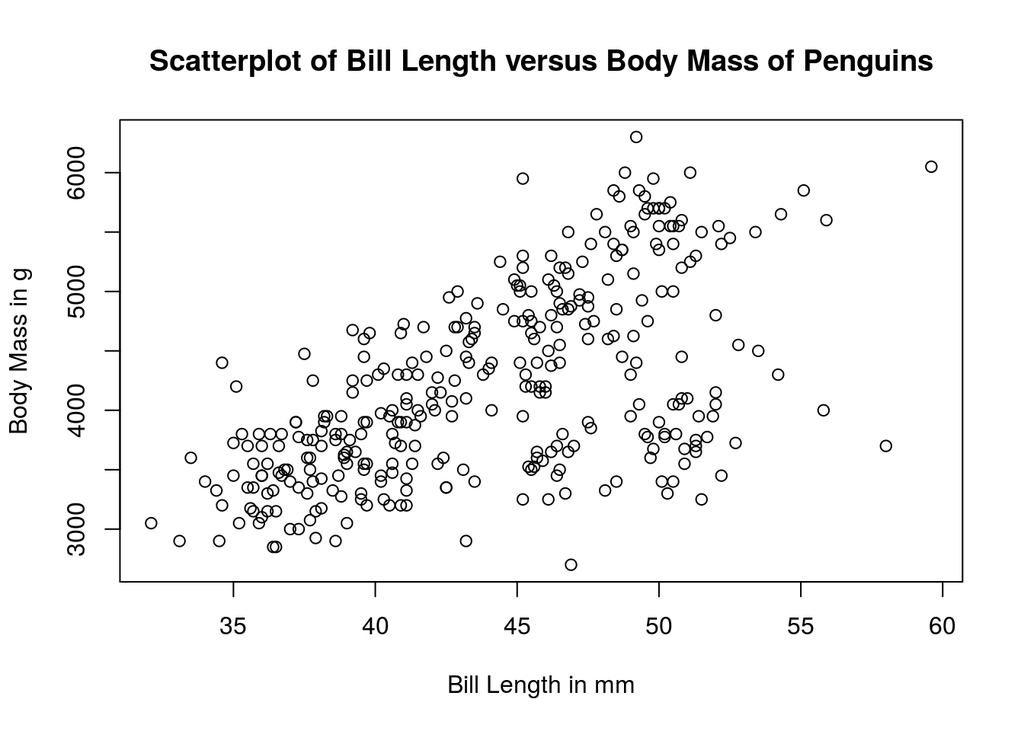

```r
plot(penguins$bill_length_mm, penguins$body_mass_g,
     main = "Scatterplot of Bill Length versus Body Mass of Penguins",
     xlab = "Bill Length in mm",
     ylab = "Body Mass in g")
```

The scatterplot of bill length versus body mass of penguins has a positive, linear association. The linear association is of moderate strength. There seem to be no unusual points (i.e. no outliers).

### Correlation in R

The correlation, denoted by the variable *r*, quantifies the strength of the linear relationship between the explanatory (*x*) and response (*y*) variable. As |r| (*the absolute value of r*) approaches 1, the linear relationship is stronger. Let’s see what the correlation *r* is for our above variables by using the `cor()` function.

The correlation, denoted by the variable *r*, quantifies the strength of the linear relationship between the explanatory (*x*) and response (*y*) variable. As |r|(*the absolute value of r*) approaches 1, the linear relationship is stronger. Let’s see what the correlation *r* is for our above variables by using the `cor()` function.

```r
cor(penguins$bill_length_mm, penguins$body_mass_g)
```

```
## [1] 0.5894511
```